# Tarea4

## Ejercicios

```r
library(pracma)
library(Matrix)
library(psych)
library(rootSolve)
library(matlib)
library(xlsx)
library(BB)
```

```r
setwd("E:/Documentos/Uni/Analisis Numerico/Tarea 4/Solucion")
```

1. Para el siguiente ejercico, instale el paquete “pracma”
1. Revise las siguientes funciones con la matriz del ejercicio 2

Sol. Las funciones realizan lo siguiente: eye(n, m = n) Retorna una matriz diagonal de tamaño n*n ones(n, m = n) Retorna una matriz llena de 1 de tamaño n*n zeros(n, m = n) Retorna una matriz llena de 0 de tamaño n*n

2. Evalue la matriz de transición para el método $\textbf{SOR}$ Sol, se añade la funcion realizada para la matriza de transición, basado en la formula para T en el metodo $\textbf{SOR}$ tomada de la bibliografia de este documento.
2. Dada la siguiente matriz, utilice las funciones del paquete para descomponer la matriz $A=L+D+U$ (Jacobi)

```r
A2 = matrix(c(-8.1, -7, 6.123, -2, -1, 4,
             -3, -1, 0, -1, -5, 0.6,
             -1, 0.33, 6, 1/2), nrow=4, byrow=TRUE)
A2
```

```
##      [,1]  [,2]   [,3] [,4]
## [1,] -8.1 -7.00  6.123 -2.0
## [2,] -1.0  4.00 -3.000 -1.0
## [3,]  0.0 -1.00 -5.000  0.6
## [4,] -1.0  0.33  6.000  0.5
```

```r
descomponer<-function(A,n){
  D<- (A*eye(n, m = n)) #Diagonal de A
  L<-A
  L[lower.tri(L, diag = TRUE) ]<-0 #triangular inferior
  U<-A
  U[upper.tri(U, diag = TRUE) ]<-0#triangular superior
  des<-D+L+U
  des
}
descomponer(A2,4)
```

```
##      [,1]  [,2]   [,3] [,4]
## [1,] -8.1 -7.00  6.123 -2.0
## [2,] -1.0  4.00 -3.000 -1.0
## [3,]  0.0 -1.00 -5.000  0.6
## [4,] -1.0  0.33  6.000  0.5
```

2. Utilice la funciÃ³n itersolve(A, b, tol , method = “Gauss-Seidel”) y solucionar el sistema asociado a la matriz $A$ con $b=[1.45,3,5.12,-4]^{t}$ con una tolerancia de $1e^-9$

```r
##Segundo B
A = matrix(c(-8.1, -7, 6.123, -2, -1, 4,
              -3, -1, 0, -1, -5, 0.6,
              -1, 0.33, 6, 1/2), nrow=4, byrow=TRUE)
b <- matrix(c(1.45,3,5.12,-4),nrow=4,ncol=1)

itersolve(A, b, tol = 1e-9, method = "Gauss-Seidel")
```

```
## $x
## [1] -3.696138e+196  2.853479e+196  1.611118e+196 -2.860899e+197
##
## $iter
## [1] 1000
##
## $method
## [1] "Gauss-Seidel"
```

3. Genere 5 iteraciones del mÃ©todo de Jacobi, calcular error relativo para cada iteracion

```r
##Segundo C
A = matrix(c(-8.1, -7, 6.123, -2, -1, 4,
             -3, -1, 0, -1, -5, 0.6,
             -1, 0.33, 6, 1/2), nrow=4, byrow=TRUE)
b <- matrix(c(1.45,3,5.12,-4),nrow=4,ncol=1)

itersolve(A, b, x0 = 1:4, nmax = 5, tol = 1e-9, method = "Jacobi")
```

```
## $x
## [1]  -12.167413    1.392056   -7.628979 -200.531199
##
## $iter
## [1] 5
##
## $method
## [1] "Jacobi"
```

3. Sea el sistema $AX=b$
1. Implemente una funciÃ³n en R para que evalue las raÃ�ces del polinomio caracterÃ�stico asociado a la matriz $A$

```
## [1] -8.864279 -5.833187  1.286718  4.810733
```

2. Use el teorema de convergencia para determinar cuál método iterativo es más favorable.

Sol La eficiencia para estos metodos iterativos esta dada por T(n) = kO(n2), con ko como el numero de iteraciones, para eso se calcula la cantidad de iteraciones que toma cada metodo para resolver la matriz A y se desbloquean las iteraciones maximas y se obtiene lo siguiente:

```r
  A = matrix(c(4, -1, -1, -1, -1, 4,
             -1, -1, -1, -1, 4, -1,
             -1, -1, -1, 4), nrow=4, byrow=TRUE)
b = c(1, 5, 1.5,-2.33)


itersolve(A, b, tol = 1e-9, method = "Gauss-Seidel")
```

```
## $x
## [1] 1.234 2.034 1.334 0.568
##
## $iter
## [1] 36
##
## $method
## [1] "Gauss-Seidel"
```

```r
itersolve(A, b, x0 = 1:4,  tol = 1e-9, method = "Jacobi")
```

```
## $x
## [1] 1.234 2.034 1.334 0.568
##
## $iter
## [1] 66
##
## $method
## [1] "Jacobi"
```

Con esto se puede ver que se obtiene un menor numero de iteraciones en la Gauss-Seidel, siendo de 36 vs 66 de JAcobi por lo que el metodo ams favorable seria el Sauss-Seidel

3. Evalue la matriz de transición para cada caso y en el caso del método de relajación determine el valor óptimo de $\omega$

```r
A = matrix(c(4, -1, -1, -1, -1, 4,
             -1, -1, -1, -1, 4, -1,
             -1, -1, -1, 4), nrow=4, byrow=TRUE)
TransicionJac<-function(A,n){
  D<- (A*eye(n, m = n)) #Diagonal de A
  L<-A
  L[lower.tri(L, diag = FALSE) ]<-0 #triangular inferior

  auxI<-inv(D)
  U<-A
  U[upper.tri(U, diag = FALSE) ]<-0#triangular superior

  Tra<-auxI*(L+U)
  Tra
}
funcTransicionSOR<-function(A,n,w){
  D<- (A*eye(n, m = n)) #Diagonal de A
  L<-A
  L[lower.tri(L, diag = FALSE) ]<-0 #triangular inferior
  aux<-(D-(w*L))
  auxI<-inv(aux)
  U<-A
  U[upper.tri(U, diag = FALSE) ]<-0#triangular superior
  aux2<-((1-w)*D)+(U*w)
  Tra<-auxI*aux2
  Tra
}
TransicionJac(A,4)
```

```
##      [,1] [,2] [,3] [,4]
## [1,]    2    0    0    0
## [2,]    0    2    0    0
## [3,]    0    0    2    0
## [4,]    0    0    0    2
```

```r
funcTransicionSOR(A,4,1.9)
```

```
##           [,1]      [,2]      [,3]      [,4]
## [1,] -1.111111  0.000000  0.000000  0.000000
## [2,]  0.000000 -1.111111  0.000000  0.000000
## [3,]  0.000000  0.000000 -1.111111  0.000000
## [4,]  0.000000  0.000000  0.000000 -1.111111
```

4. Teniendo en cuenta lo anterio resolver el sistema

```r
A = matrix(c(4, -1, -1, -1, -1, 4,
-1, -1, -1, -1, 4, -1,
-1, -1, -1, 4), nrow=4, byrow=TRUE)
A
```

```
##      [,1] [,2] [,3] [,4]
## [1,]    4   -1   -1   -1
## [2,]   -1    4   -1   -1
## [3,]   -1   -1    4   -1
## [4,]   -1   -1   -1    4
```

```r
b = c(1, 5, 1.5,-2.33)


itersolve(A, b, tol = 1e-5, method = "Gauss-Seidel")
```

```
## $x
## [1] 1.2339811 2.0339836 1.3339858 0.5679876
##
## $iter
## [1] 20
##
## $method
## [1] "Gauss-Seidel"
```

```r
itersolve(A, b, x0 = 1:4,  tol = 1e-5, method = "Jacobi")
```

```
## $x
## [1] 1.2340682 2.0340682 1.3340682 0.5680682
##
## $iter
## [1] 34
##
## $method
## [1] "Jacobi"
```

```r
solucion<- solve(A,b)


A = matrix(c(4, -1, -1, -1, -1, 4,
             -1, -1, -1, -1, 4, -1,
             -1, -1, -1, 4), nrow=4, byrow=TRUE)
A
```

```
##      [,1] [,2] [,3] [,4]
## [1,]    4   -1   -1   -1
## [2,]   -1    4   -1   -1
## [3,]   -1   -1    4   -1
## [4,]   -1   -1   -1    4
```

```r
b = c(1, 5, 1.5,-2.33)
solve(A,b)
```

```
## [1] 1.234 2.034 1.334 0.568
```

1. Pruebe el siguiente algoritmo con una matriz $A_{3}$, modifiquelo para quue $a_{ii}=0$ para todo $i$

```r
tril1 <- function(M, k = 0) {
if (k == 0) {
M[upper.tri(M, diag = FALSE)] <- 0
} else {
M[col(M) >= row(M) + k + 1] <- 0
}
return(M)
}

##Modificado:

tril1 <- function(M, k = 0) {
  if (k == 0) {
    M[upper.tri(M, diag = FALSE)] <- 0
  } else {
    M[col(M) >= row(M) + k + 1] <- 0
  }
  D1<-eye(row(M), col(M))
  D2<-ones(row(M), col(M))
  D4<-(-1*(D1-D2))
   M<-M*D4
  return(M)
}
```

2. Implemente una funciÃ³n en R para que dada una matriz $A$ se obtenga una matriz diagonal $D$ donde en la diagonal estan los mismo elementos de A
4. Cree una función que cuente el número de multiplicaciones en el método directo de Gauss Jordan, para resolver un sistema de $n$ ecuaciones y pruebelo para $n=5$

```
##      [,1] [,2] [,3] [,4] [,5] [,6]
## [1,]   20   16  -18  -28   -2  -15
## [2,]   14   16  -28  -25   17   26
## [3,]  -21    3  -13   12   -1  -24
## [4,]   18  -10   13   -6    6   18
## [5,]  -29    2  -26   -6   12   23
```

```
##      [,1] [,2] [,3] [,4] [,5]      [,6]
## [1,]    1    0    0    0    0 -1.908872
## [2,]    0    1    0    0    0  2.786432
## [3,]    0    0    1    0    0  3.604952
## [4,]    0    0    0    1    0 -1.820118
## [5,]    0    0    0    0    1  3.739823
```

```
## Multiplicaciones 20
```

5. Dado el siguiente sistema:

   $2x-z=1$
   $\beta$x+2y-z=2
   $-x+y+$$z=1$
1. Encuentre el valor de $\alpha$ y $\beta$ para asegura la convergencia por el mÃ©todo de Jacobi
2. Genere una tabla que tenga 10 iteraciones del mÃ©todo de Jacobi con vector inicial $x_{0}=[1,2,3]^t$
3. Grafique cada ecuación y la soñlución

```r
jacobi<-function(a,ciclos) {
  n<-nrow(a)
  id <- diag(x = 1, nrow=n, ncol=n )
  Q<-id
  for (k in 1:ciclos) {
    for ( i in 1:(n-1)) {
      for ( j in (i+1):n) {
        control <- 10^(-k)
        if( abs(a[i,j]) > control) {
          print(c(a[i,j],control))
          angulo <- 0.5*atan(2*a[i,j]/(a[i,i] - a[j,j]))
          c<-cos(angulo)
          s<-sin(angulo)
          p<-id
          p[i,i]<-c
          p[j,j]<-c
          p[i,j]<--s
          p[j,i]<- s
          Q <- Q%*%p
          a<-t(p)%*%a%*%p
          a[i,j]<-0
          a[j,i]<-0

        }
      }
    }
    cat("estado: ", a, "\n")
  }
  return(list(raices=diag(a),vectores=Q,estado=a))
}

# Aplicacion
A<-rbind(c(2, 0, -1),c(1, 2,-1),c(-1,1,2))
jacobi(A,10)
```

```
## [1] -1.0  0.1
## estado:  3 1.414214 0 -0.7071068 2 0.7071068 0 -1.110223e-16 1
## [1] -0.7071068  0.0100000
## estado:  2.5 0 -0.3250576 0 2.5 0.627963 5.103705e-17 -9.8596e-17 1
## estado:  2.5 0 -0.3250576 0 2.5 0.627963 5.103705e-17 -9.8596e-17 1
## estado:  2.5 0 -0.3250576 0 2.5 0.627963 5.103705e-17 -9.8596e-17 1
## estado:  2.5 0 -0.3250576 0 2.5 0.627963 5.103705e-17 -9.8596e-17 1
## estado:  2.5 0 -0.3250576 0 2.5 0.627963 5.103705e-17 -9.8596e-17 1
## estado:  2.5 0 -0.3250576 0 2.5 0.627963 5.103705e-17 -9.8596e-17 1
## estado:  2.5 0 -0.3250576 0 2.5 0.627963 5.103705e-17 -9.8596e-17 1
## estado:  2.5 0 -0.3250576 0 2.5 0.627963 5.103705e-17 -9.8596e-17 1
## estado:  2.5 0 -0.3250576 0 2.5 0.627963 5.103705e-17 -9.8596e-17 1
```

```
## $raices
## [1] 2.5 2.5 1.0
##
## $vectores
##            [,1]       [,2]      [,3]
## [1,]  0.6279630  0.3250576 0.7071068
## [2,] -0.4597008  0.8880738 0.0000000
## [3,] -0.6279630 -0.3250576 0.7071068
##
## $estado
##            [,1]     [,2]          [,3]
## [1,]  2.5000000 0.000000  5.103705e-17
## [2,]  0.0000000 2.500000 -9.859600e-17
## [3,] -0.3250576 0.627963  1.000000e+00
```

```r
Jacobi<- function(ciclos){
  A <- matrix(c(2, 0, -1,1, 2,-1,-1,1,3),nrow=3,ncol=3)
  B<- matrix(c(1,2,1), nrow =3, ncol=1)
  Xk<-matrix(c(1,2,3),nrow =3, ncol =1)
  L<- lower.tri(A, diag = FALSE)
  U<- upper.tri(A, diag = FALSE)
  D<- diag(x=1,nrow =3 ,ncol=3, names = TRUE)
  R<-L+U


  cat("X0: ", Xk, "\n")
  for (k in 1:ciclos)
  {
    P<-(R%*%Xk)
    Xk<-(1/det(A)*(D))%*%(B-P)
    cat("X",k,": ", Xk, "\n")
    k<-k+1
  }
}
Jacobi(10)
```

```
## X0:  1 2 3
## X 1 :  -0.3636364 -0.1818182 -0.1818182
## X 2 :  0.1239669 0.231405 0.1404959
## X 3 :  0.05709992 0.1577761 0.05860255
## X 4 :  0.0712383 0.1712998 0.07137491
## X 5 :  0.06884776 0.1688533 0.06886017
## X 6 :  0.06929877 0.1692993 0.0692999
## X 7 :  0.06921826 0.1692183 0.06921836
## X 8 :  0.06923303 0.169233 0.06923304
## X 9 :  0.06923036 0.1692304 0.06923036
## X 10 :  0.06923084 0.1692308 0.06923084
```

6. Instalar el paquete Matrix y descomponga la matriz $A$ (del punto dos) de la forma $LU$ y la factorizarla como $A=QR$

```
## A = QR:
## 9.433333 4.78 -4.789667 1.933333 7.066667 1.113333 -1.748667 1.6 6.733333 2.78 -1.082 1.066667 7.066667 2.336667 -4.748667 1.1
```

1. Determinar numéricamente la intersección entre la circunferencia $x^2 + y^2 = 1$ y la recta $y = x$. Usamos una aproximación inicial $(1,1)$. Utilice el pauqte BB y la función BBsolve() del paquete,grafique la solución b Analizar y comentar el siguinte código

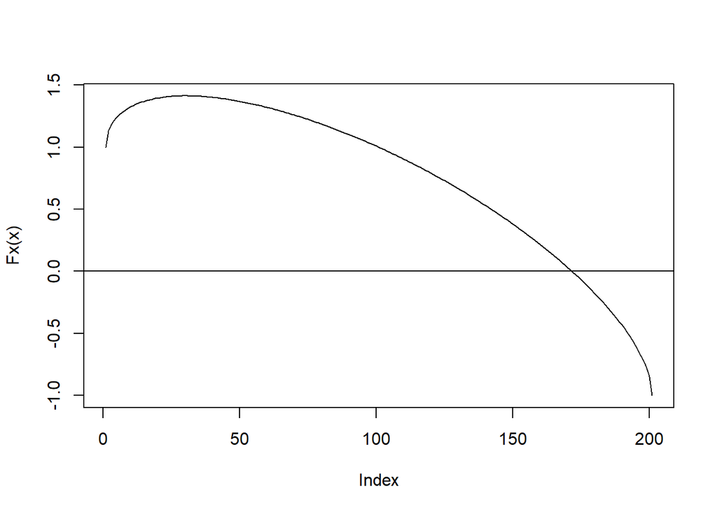

```
## Solucion= 0.5     Error= 0.2320508    Iteracion= 1
## Solucion= 0.7886751   Error= 0.07616322   Iteracion= 2
## Solucion= 0.6957109   Error= 0.01148628   Iteracion= 3
## Solucion= 0.7064095   Error= 0.0006976451     Iteracion= 4
## Solucion= 0.7071124   Error= 5.571976e-06     Iteracion= 5
## Solucion= 0.7071068   Error= 2.746025e-09     Iteracion= 6
```

```
##   Successful convergence.
```

[output not shown]

[output cut: 1652 more lines]

8. Demuestre y realice varias pruebas que la matriz de transición por el método de Gauss-Seidel esta dada por $T=(-D^{-1}U)(I+LD^{-1})^{-1}$

Referencias:

- https://numericalmethods2014.wordpress.com/s-o-r/
- https://profs.info.uaic.ro/~fliacob/An2/2012-2013/Resurse/Relative%20la%20Matlab/Faddeev_Leverrier%20Method%20for%20matrices.pdf